# Análisis de las condiciones del océano frente a Perú durante el año 1990 - Tercer Examen Programación Científica

Lucía Maldonado Cruzado

9 de Julio del 2017

# Introducción

Se realizó el análisis de las condiciones oceánicas frente a las costas de Perú durante el año 1990. Se utilizaron datos de temperatura superficial del mar (TSM), salinidad en UPS y fitoplancton pequeño y grande (micromol por metro cuadrado por segundo) proporcionados por el profesor del curso. Los gráficos se realizaron con Rstudio utilizando los paquetes:

- **ncdf4**
- **fields**
- **kali**

# Materiales y métodos

Para lograr realizar los gráficos que caracterizan las costas de Perú durante 1990 se proporcionaron 4 bases de datos. La propiedad que mejor describe el ecosistema costero es la temperatura superficial del mar que se extrajo del archivo *“sst.nc4”* como temperatura potencial superficial. Las unidades se encontraban en grados celcius por lo que no se tuvo que hacer ninguna conversión. De este mismo archivo de temperaturas se extrajeron los márgenes de latitud y longitud que se recortaron para realizar solo el análisis en el mar peruano.

El archivo sss.nc4 se utilizó para extraer los datos de salinidad en unidades UPS. Posteriormente se obtuvieron los datos de fitoplancton de los archivos *“lphy.c4”* y *“sphy.nc4”* que tuvieron que ser modificados para obtener la abundancia de fitoplancton en micromoles por metro cuadrado al segundo.

# Resultados

## Análisis Temperatura Superficial del Mar

El Perú es un país que se encuentra en una zona tropical, sin embargo no posee un clima tropical lo que se debe a la temperatura del mar que influencia la temperatura del aire y a su vez crea una atmósfera estable. Esta atmósfera estable se caracteriza por una barrera de nubes que cubre la mayor parte de la costa peruana. Los vientos cálidos no pueden atravesar esta barrera y a su vez esta también refleja gran cantidad de la radiación solar que calentaría el mar.

Debido a la gran importancia de la regulación atmosférica que posee nuestro mar, su estudio es necesario y es por ello que se toman constantemente medidas de la temperatura del mar a lo largo de series de tiempo muy extensas. En este estudio se concentra la información obtenida en el año 1990.

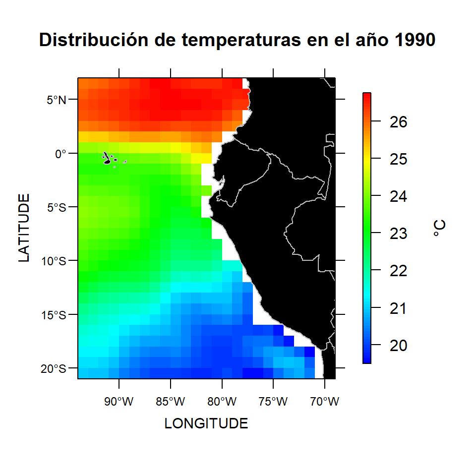

En el gráfico de distribución de temperaturas en el año 1990 se observa que a lo largo de la costa peruana las temperaturas no sobrepasan los 24°C. y que a partir de la costa central las temperaturas bajan hasta los 20°C y menos. Sim embargo, este resultado podría estár sesgado ya que el promedio de la temperatura total del año contiene tanto los meses de verano, con anomalías cálidas, como los meses de inverno, con anomalías frías. Según la bibliografía el año 1990 presenta anomalías frías predominantes, lo que se espera ver en los siguientes gráficos.

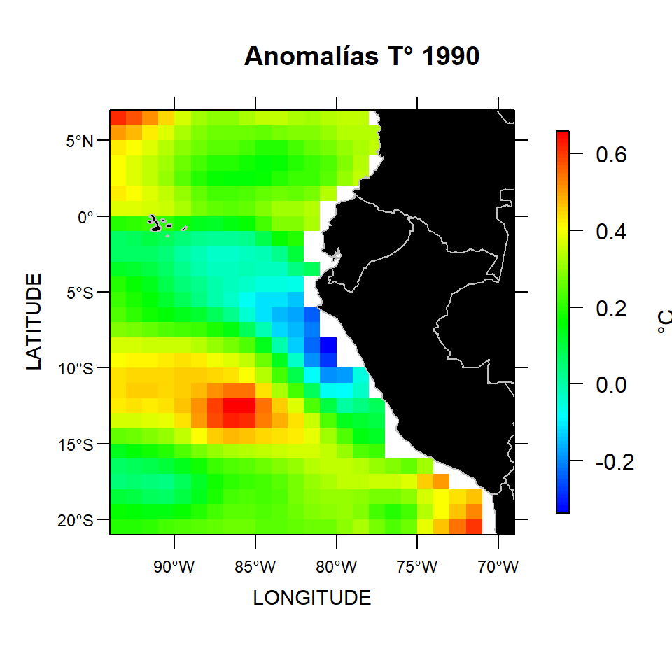

Cuando comparamos el año 1990 con el resto de los datos proporcionados que abarcan 46 años de nuestreo de TSM, se puede observar una anomalía negativa en el norte de la costa peruana lo que indicaría que es un año con tendencia fría como menciona la bibliografía consultada.

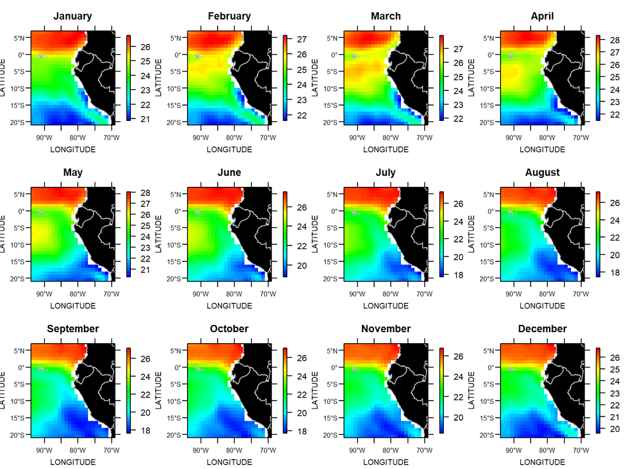

EVOLUCIÓN MENSUAL DE LA TEMPERATURA DURANTE EL AÑO 1990

Cuando vemos el gráfico de las diferencias de temperatura a lo largo de todos los meses del año se observa la estacionalidad bien marcada siendo los meses más fríos los de julio, agosto y setiembre, que vendrían a representar el invierno en el hemisferio sur. A partir del mes de julio se hace evidente este enfriamiento sobretodo a partir de los 10°S llegando a temperaturas de 18°C.

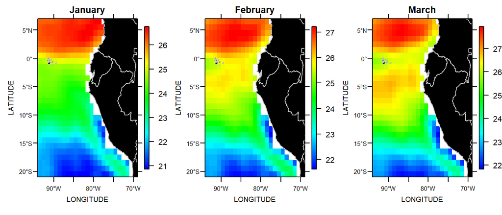

VARIACIÓN DE TEMPERATURAS EN VERANO 1990

Como se sabe las costas peruanas son altamente productivas y esto se debe a que se trata de un ecosistema que está influenciado por la surgencia de aguas profundas que traen consigo nutrientes que desecadenan el desarrollo de la producción primaria y por ende impulsan la productividad del ecosistema en general. Una manera de notar la presencia de este levantamiento de aguas profundas es mediante la diferencia de temperaturas en la costa. Al subir estas aguas profundas logran disminuir la temperatura costera, este fenómeno es más evidente en el verano ya que la temperatura promedio de incrementa en los meses de verano (24°C) sin embargo, las aguas de surgencia mantienen una temperatura baja (22°C).

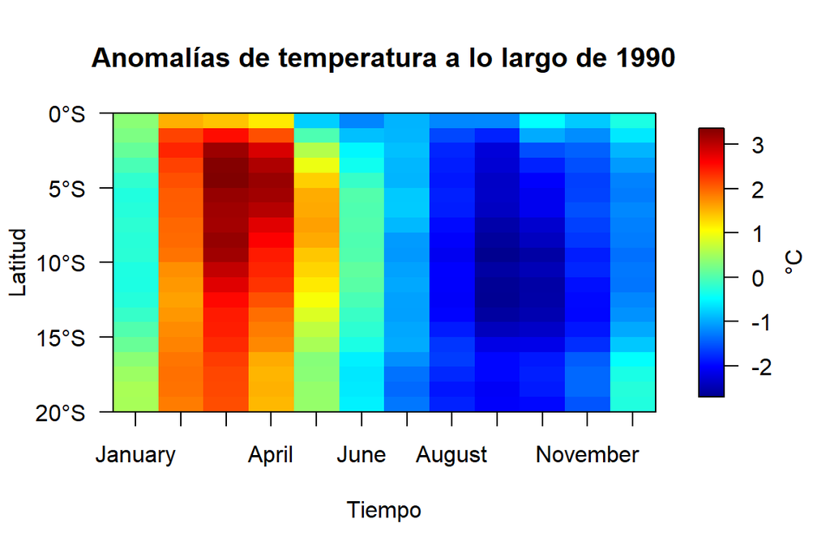

Diagrama Hovmoller

En el diagrama hovmoller de anomalías a lo largo del año 1990 se puede identificar fácilmente que la mayor anomalía de temperatura se da en el mes de marzo alcanzando más de 3 grados de anomalía. Por otro lado en el mes de setiembre se encuentra la mayor anomalía negativa alcanzando temperaturas con anomalías negativas menores a -2°C.

Las anomalías frías fueron más extensas a lo largo de la costa peruana y también en el tiempo ya que la mayor predominancia en el año es de anomalías frías (desde junio hasta diciembre). Las anomalías positivas fueron más intensas hasta los 10°S y en los meses de marzo y abril.

## Análisis de Salinidad

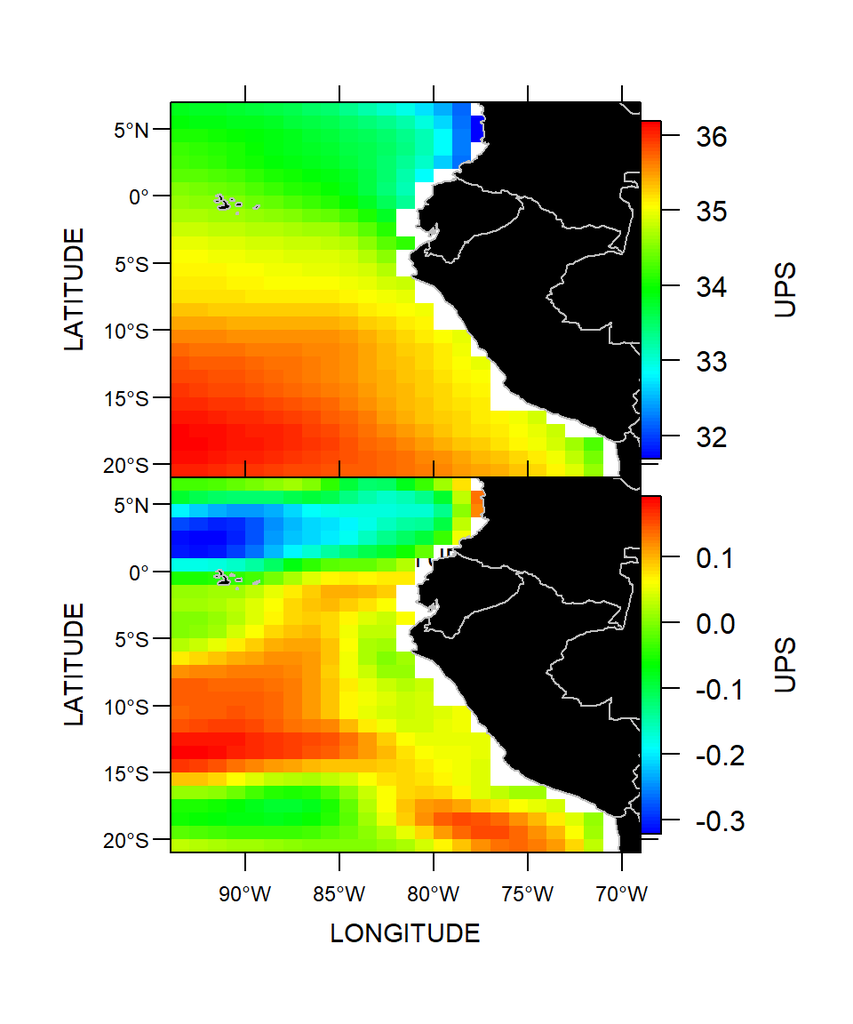

Salinidad promedio y anomalías durante 1990 (UPS)

El año 1990 presenta una salinidad alta mayor a 35 UPS, sin embargo, para el gráfico de anomalías se observa una ligera anomalía negativa en el promedio, es necesario analizar cada mes para localizar en qué momento del año se desarrolla dicha anomalía.

Esto coincide con la bibliografía que menciona que las salinidades estuvieron por encima de 35.1%. que en general presenta valores altos debido a la predominancia de Aguas Subtropicales Superficiales. La disminución hasta 34.6 que se observa en el siguiente gráfico en el mes de abril podría explicarse con la presencia de aguas costeras frías o también aguas de surgencia.

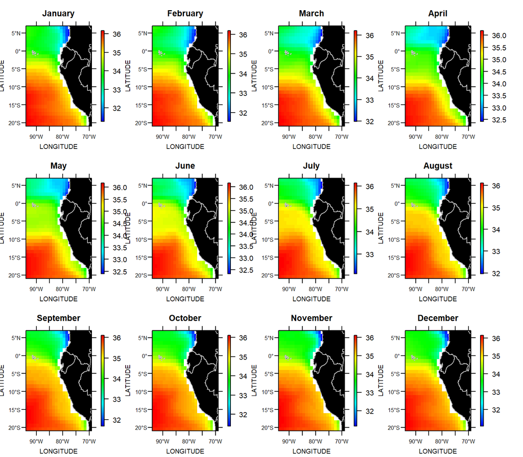

Salinidad mensual durante 1990 (UPS)

Como se observa en la imagen superior la salinidad disminuye en los meses de marzo y abril y tiene la mayor salinidad en enero. A continuación se comparará la salinidad con la temperatura de ambos meses.

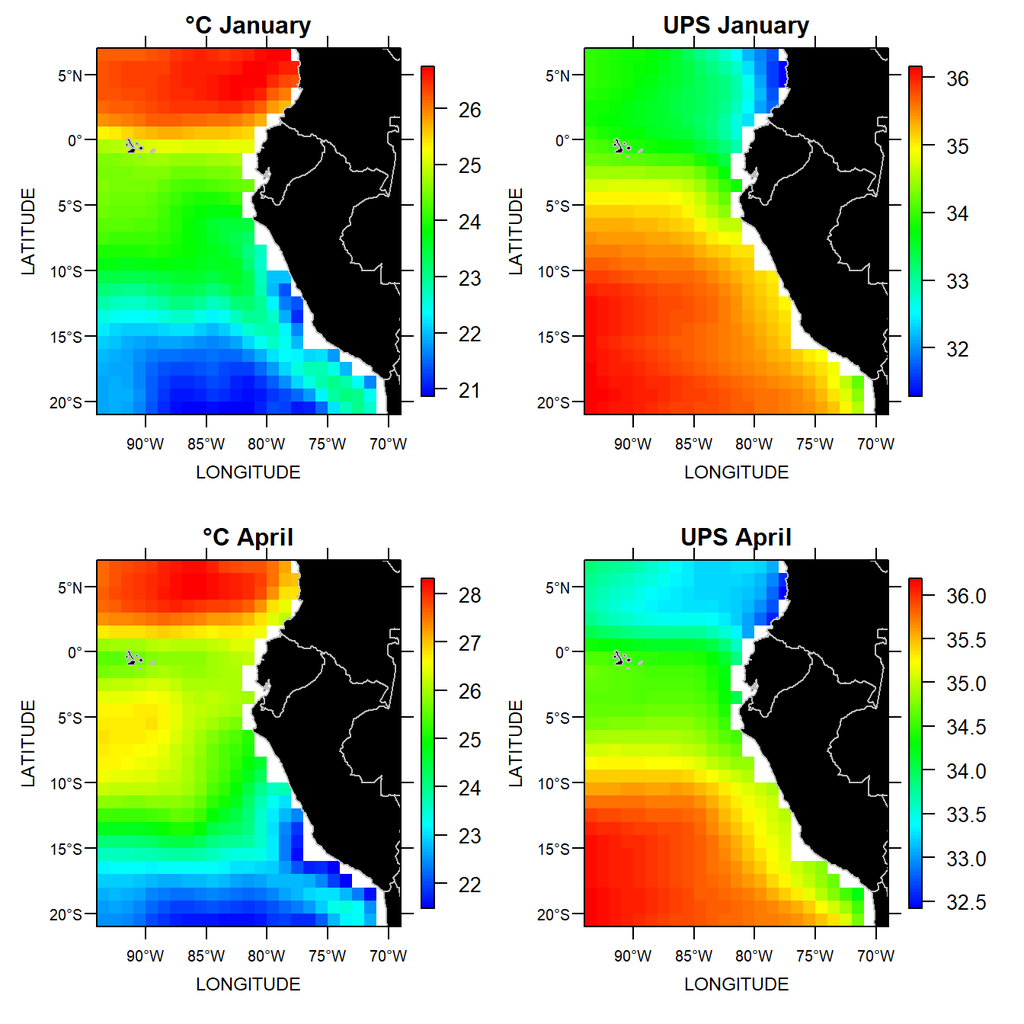

Temperatura vs Salinidad

## Análisis de Producción primaria

El ecosistema peruano es altamente productivo y eso se evidencia en la abundancia de fitoplancton. Las diferencias en el tamaño del fitoplancton también significan diferencias en la disponibilidad de nutrientes y condiciones físicas como la turbulencia, y la surgencia de aguas profundas. Según la bibliografía cuando existe una menor disponibilidad de nutrientes el fitoplancton suele ser de menor tamaño ya que la absorción de estos es más eficiente, en este caso se encontrarían más dinoflagelados. Normalmente los periodos de surgencia están asociados a una mayor disponibilidad de nitratos lo que beneficiaría la proliferación de fitoplancton de mayor tamaño como las diatomeas.

### Promedio general de fitoplancton

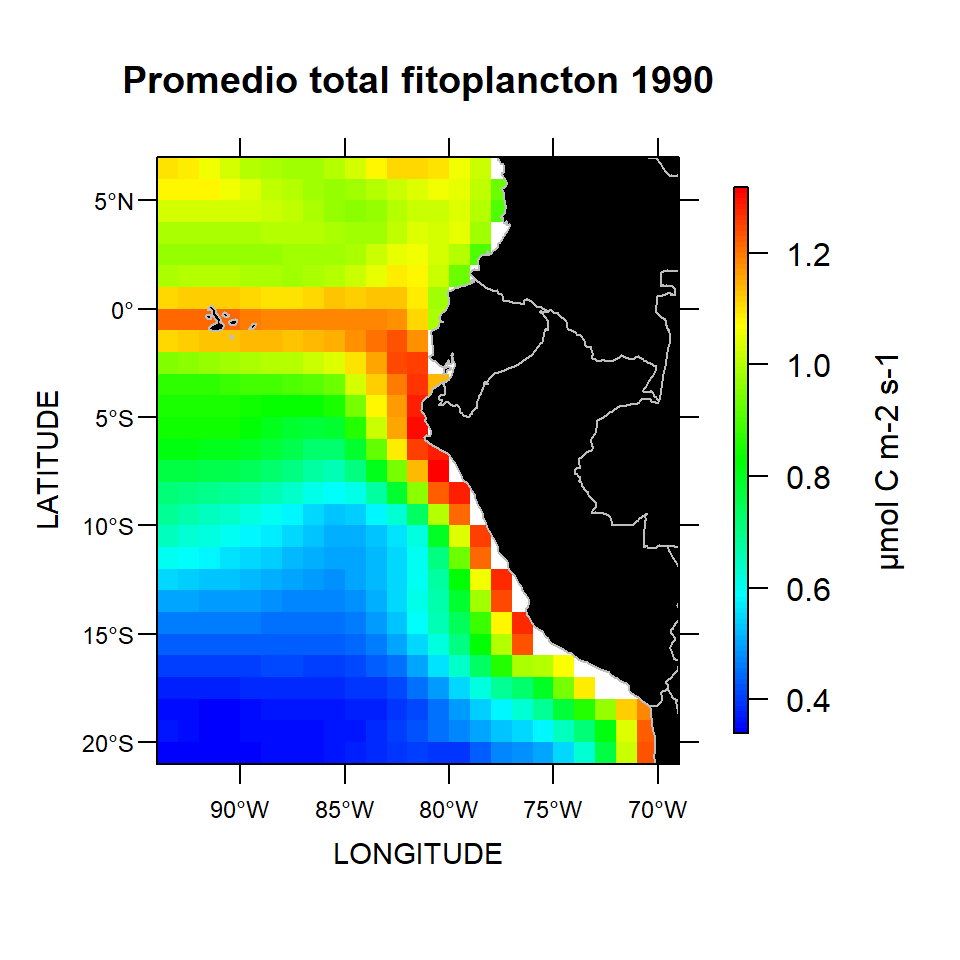

La mayor abundancia de fitoplancton se encuentra cercana a la costa peruana sostenida por la alta productividad del sistema de surgencia además de los nutrientes proporcionados por la plataforma. Aparte se puede observar la abundancia a la largo de la Zona de convergencia intertropical.

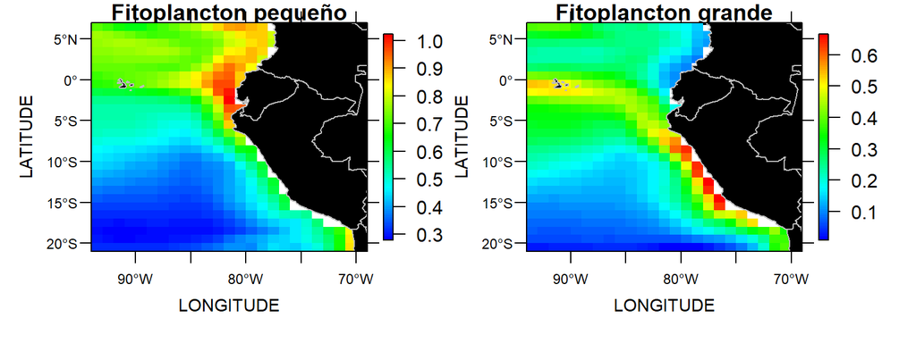

Fitoplancton pequeño vs grande micromol/m2/s

Las diferencias entre ambos gráficos son notorias, sin embargo, se debe tener en cuenta la escala que es mucho mayor para el fitoplancton pequeño lo que demuestra su predominancia a lo largo de la costa peruana en el año 1990. El fitoplancton grande representado por las diatomeas presenta su mayor abundancia a lo largo de la costa hasta Nazca en donde disminuye, esto estaría asociado al tamaño de la plataforma que al incrementar la latitud esta disminuye.

### Fitoplancton pequeño

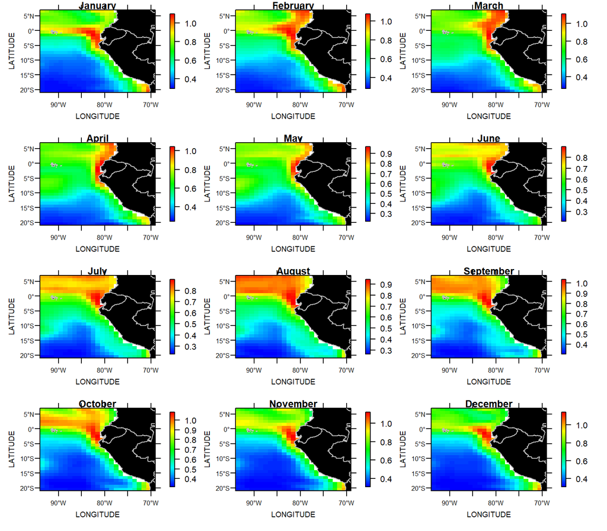

Fitoplancton pequeño micromol/m2/s

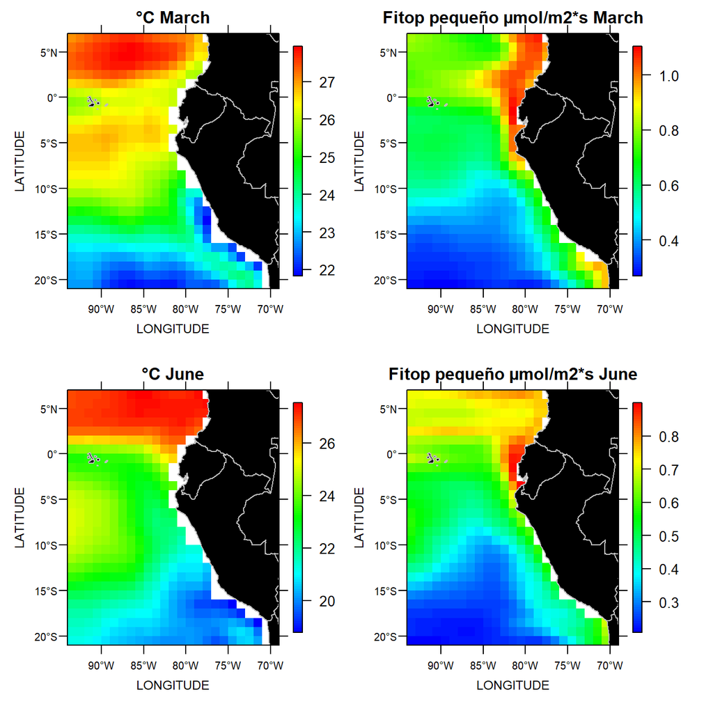

Temperatura vs Fitopqueño

Se evidencia una diferencia más notoria en la distribución del fitoplancton más que en la abundancia en relación a las estaciones y sus respectivas temperaturas. En el norte del Perú a la altura de Tumbes se llegan a valores de 1µmol por metro cuadrado en el mes de verano (marzo) con temperaturas promedio acercándose a los 27°C. También se observa una abundancia de 0.9 µmol en el sur del país (Tacna).

### Fitoplancton grande

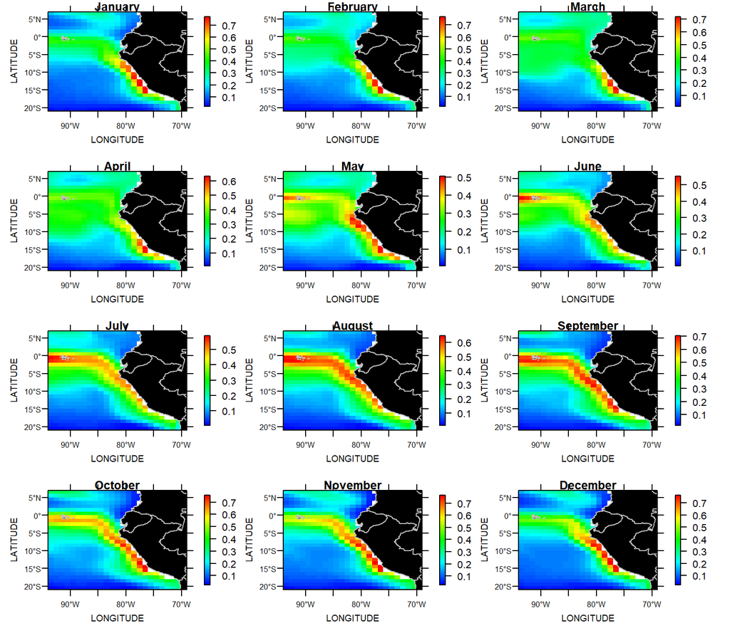

Fitoplancton grande micromol/m2/s

## Referencias

- Marco Espino et. al. IMARPE. 1990. - *“Situación de los stocks de peces demersales en el otoño 1990”*.
- CENEPRED. 2013. - *“Escenario de Riesgos ante el Fenómeno La Niña en la costa del Perú / Perú. Centro Nacional de Estimación, Prevención y Reducción del Riesgo de Desastres. Lima: CENEPRED.”*